# New kernel for Metropolis Hasting (bridging the gap with variational inference)

$\newcommand{\expec}{\mathbb{E}}$ $\newcommand{\prob}{\mathbb{P}}$ $\newcommand{\indic}{\mathbb{1}}$ $\DeclareMathOperator*{\argmax}{arg\,max}$

In this document, we will introduce a new proposal for our Metropolis hastings algorithm. The construction of this kernel is based off of approximation methods that consist in approximating the incomplete log likelihood. The following methods are applicable to continuous and discrete hierarchical models (the likelihood is whether discrete or continuous and the prior on the latent variable is always continuous).

# The Model

We study a classical missing data problem where:

- The observed data is a continuous random variable $Y = (Y_i, 1\leq i \leq N)$ that has observed values $(y_i, 1\leq i \leq N)$ in $\mathcal{Y}$
- The latent data is a continuous random variable $\psi = (\psi_i, 1\leq i \leq N)$ that takes on the values $(\psi_i, 1\leq i \leq N)$ in $\mathcal{Z}$ and consists in $N$ independent variables
- The components $Y_i$ are generated independently of each other and from their corresponding $\psi_i$
- $\log p(y,\theta)$ is the incomplete data log-likelihood
- $\log p(y,z,\theta)$ is the complete data log-likelihood and obtained by augmenting the observed data with the missing data
- We’ll call $P_{Y_i,\psi_i,\theta}$ and $P_{\psi_i|Y_i,\theta}$ the probability distributions associated to the densities $p(y_i,\psi_i,\theta)$ and $p(\psi_i|y_i,\theta)$

Our objective is to create samples from the posterior distribiution $P_{\psi_i|Y_i,\theta}$ for all individuals i and at a fixed model parameter $\theta$.

In this document, we will consider N i.i.d. observations $y=(y_i, 1\leqslant i \leqslant N)$, unobserved individuals parameters $\psi=(\psi_i, 1\leqslant i \leqslant N)$ and a vector of parameters $\theta$. The goal is to find the parameter $\theta$ that maximizes the likelihood $p(y;\theta)$:

$$p(y;\theta) = \int_{}^{} p(y,\psi;\theta) \, \mathrm{d}\psi$$

We are going to restrict ourselves to models that belong to the exponential family. The complete data log likelihood can be expressed as:

$$\log p(y, \psi; \theta) = -\phi(\theta) + \langle S(y,\psi){,} \Phi(\theta) \rangle$$

With $\langle \cdot{,} \cdot \rangle$ being the scalar product and $\phi(\theta)$, $\Phi(\theta)$ and $S(y,\psi)$ are known functions.\ We consider a joint model for the observations $y = (y_i, 1\leqslant i \leqslant N)$ and the individual parameters $\psi = (\psi_i, 1\leqslant i \leqslant N)$:
$$p(y, \psi; \theta) = p(y|\psi; \theta)p(\psi; \theta)$$
Where $p(y|\psi; \theta)$ is the conditional distribution of the observations of individual $i$ and $p(\psi; \theta)$ the distribution of the individual parameters. Also:

$$\begin{split}
& y_i = f(t_i)+\sigma\epsilon_i \textrm{ with $\epsilon_i\sim \mathcal{N}(0,1)$}\\
&\psi_i = c_i*\psi_{pop}+\eta_i\textrm{ with $\eta_i\sim \mathcal{N}(0,\Omega)$}
\end{split}$$

$$\begin{split}
& y_i|\psi_i \sim \mathcal{N}(f(t),\sigma)\\
& \psi_i \sim \mathcal{N}(\psi_{pop}, \Omega)
\end{split}$$

# Introduction to approximation methods

## Laplace approximation

Laplace approximation consists in approximating an integral of the form:
$$I(m) := \int{e^{mg(x)}dx}$$
Where $m \in \mathbb{R}$ and g is three times differentiable.

Based on a second order taylor expansion of the function g around a point $x_0$ we get:
$$g(x) = \underbrace{g(x_0) + \nabla g(x_0)(x-x_0) +\frac{1}{2}(x-x0)\nabla^2g(x_0)(x-x0)}_{=\tilde{g}(x)} + R(x)$$

Which results in an approximation of the integral $I(m)$ (easier integral and consider a multivariate gaussian which integral sums to 1):
$$I(m)=e^{mg(x_0)}\sqrt(\frac{(2\pi)^p}{m|-\nabla^2g(x_0)|}) e^{-1/2m\nabla g(x_0)\nabla^2g(x_0)^{-1}\nabla g(x_0)}$$

## Application to our missing data problem

In our context we can easily write the inomplete likelihood, that we are trying to approximate, as for all parameters $\theta$:
$$\begin{split}
p(y,\theta) &= \int{p(y,z,\theta)dz}\\
& = \int{e^{\log p(y,z,\theta)}dz}
\end{split}$$

In this case we identify $g(z) = \log p(y,z,\theta)$. In the sequel we can lose dependence on the parameter $\theta$ since the model parameter stays constant throughout the MCMC. We’ll get it back when dealing with the SAEM algorithm. Also
$$\begin{split}
g(z) &=\log p(y|z)+\log p(z) \\
& = \log l(z) + \log h(z)
\end{split}$$
For the first two methods that we will introduce (Laplace and First order conditional estimation methods), we do a taylor expansion around the Maximum a Posteriori (MAP) (also known as Empirical bayes estimate (EBE)). As a result $\nabla g(z_0)=0$ with $z_0 = \arg \max \limits_{z}p(y,z)$. In the third example, called First Order method, the taylor exapnsion is done around the expectation of the random variable z: $z_0 = \expec{z}$. Thus $\nabla g(z_0)$ is not equal to $0$. Also, we will apply previous results with $m=1$

### Laplacian Method

Using last derivation of the approximation of the integrale $I(m)$ we can explicit an approximation of our incomplete log likelihood:
$$\begin{split}
-2\log p(y) & \approx -p\log2\pi - 2\log p(y,z_0) + \log |-\nabla^2 g(z_0)|\\
& \approx - 2\log p(y|z_0) - 2\log p(z_0) -p\log2\pi + \log |-\nabla^2 g(z_0)|
\end{split}$$
Since this last equ tion approximates (Bayes)
$$\log p(y) = \log p(y|z_0) + \log p(z_0) - \log p(z_0|y)$$
We can say that $-p\log2\pi + \log |-\nabla^2 g(z_0)|$ approximates $- \log p(z_0|y)$. Notice that $-p\log2\pi + \log |-\nabla^2 g(z_0)|$ is the value of a multivariate gaussian centered in $z_0$ and of covariance $|-\nabla^2 g(z_0)|$ taken in $z=z_0$. As a result the laplacian method consist in, through an approximation of the incomplete log likelihood, approximating the posterior distribution $P_{Z|Y}$ as a multivariate gaussian centered in $z_0$ and of covariance $|-\nabla^2 g(z_0)|$. Where:
$$\nabla^2 g(z_0) = \nabla^2 \log l(z_0) + \nabla^2 \log h(z_0)$$

$$Z \sim \mathcal{N}(Z_{MAP}, (\frac{\nabla^2 l(z_0)}{l(z_0)} - \frac{\nabla l(z_0)\nabla l(z_0)}{l^2(z_0)} +\Omega^{-1})^{-1})$$

### FOCE (First order conditional estimation)

In the case where the calculus of $\nabla^2 \log l(z_0)=\nabla^2 \log p(y|z_0)$ is hard, Wang (2007) introduced an approximation :
$$\begin{split}
\nabla^2 \log l(z_0) & \approx \mathbb{E}^Z(\nabla^2 \log l(z_0))\\
& \approx - \frac{\nabla l(z_0)\nabla l(z_0)}{l^2(z_0)} = - \frac{\nabla f(z_0)\nabla f(z_0)}{\sigma^2}
\end{split}$$
As a result the laplacian method consist in, through an approximation of the incomplete log likelihood, approximating the posterior distribution $P_{Z|Y}$ as a multivariate gaussian centered in $z_0$ and of covariance $|-\nabla^2 g(z_0)| = (- \frac{\nabla f(z_0)\nabla f(z_0)}{\sigma^2}+\omega^{-1})^{-1}$ This is the first method I implemented.

$$Z \sim \mathcal{N}(Z_{MAP}, (- \frac{\nabla l(z_0)\nabla l(z_0)}{l^2(z_0)} +\Omega^{-1})^{-1})$$

### FO (First order)

This method consists in doing the TD around the mean of the prior (fixed effect in the context of our models). As a result the gradient of $g(z) = \log p(y,z)$ is not null in $z=z_0$.

$$Z \sim \mathcal{N}(Z_{MEAN}, (- \frac{\nabla l(z_{MEAN})\nabla l(z_{MEAN})}{l^2(z_{MEAN})} +\Omega^{-1})^{-1})$$

# MCMC proposals in the context of non linear mixed effects models

### Linear case (20 individuals 10 obs per individual)

$$y_i = y(t_i) = f(\psi_i)+ \epsilon_i$$
With :

$$f(\psi_i) = b_i*t+d_i$$

#### Autocorr and msjd

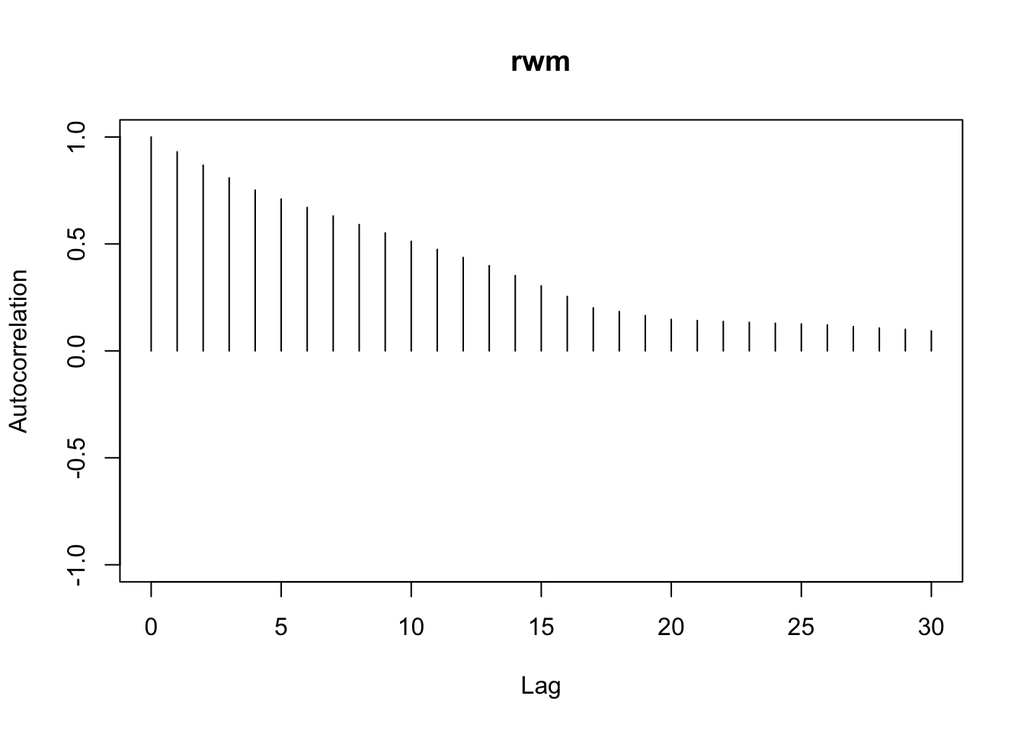

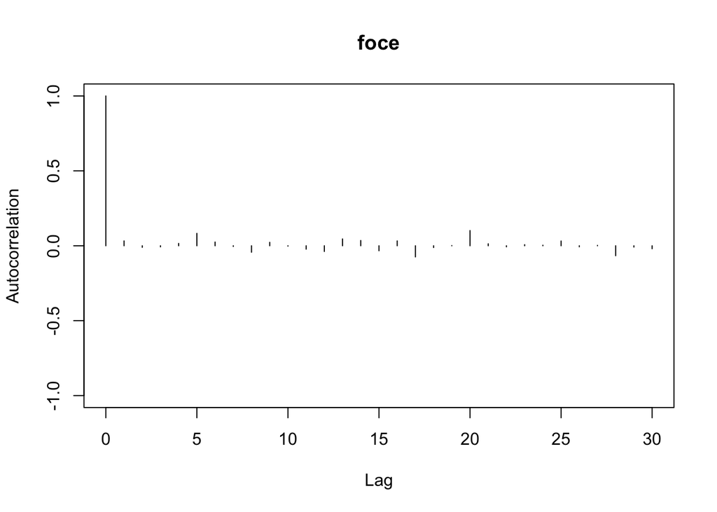

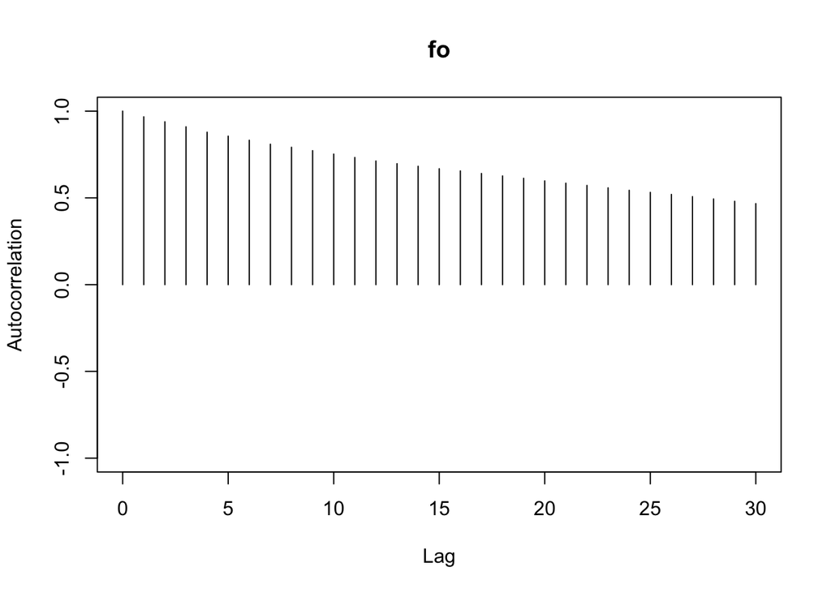

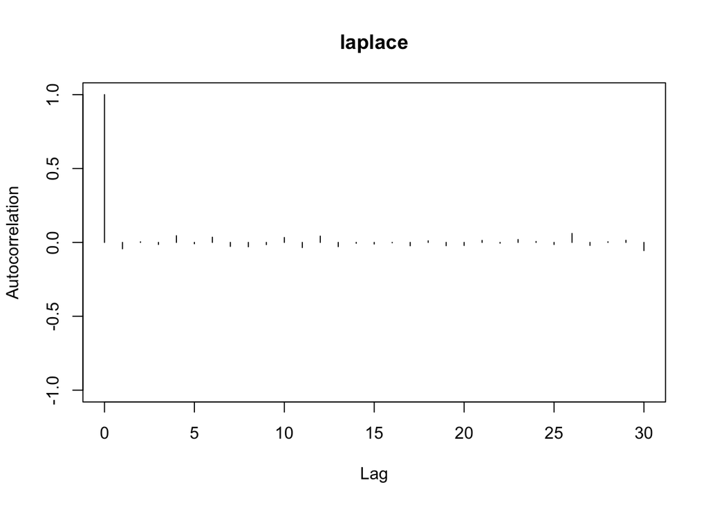

#### Posterior samples for one individual

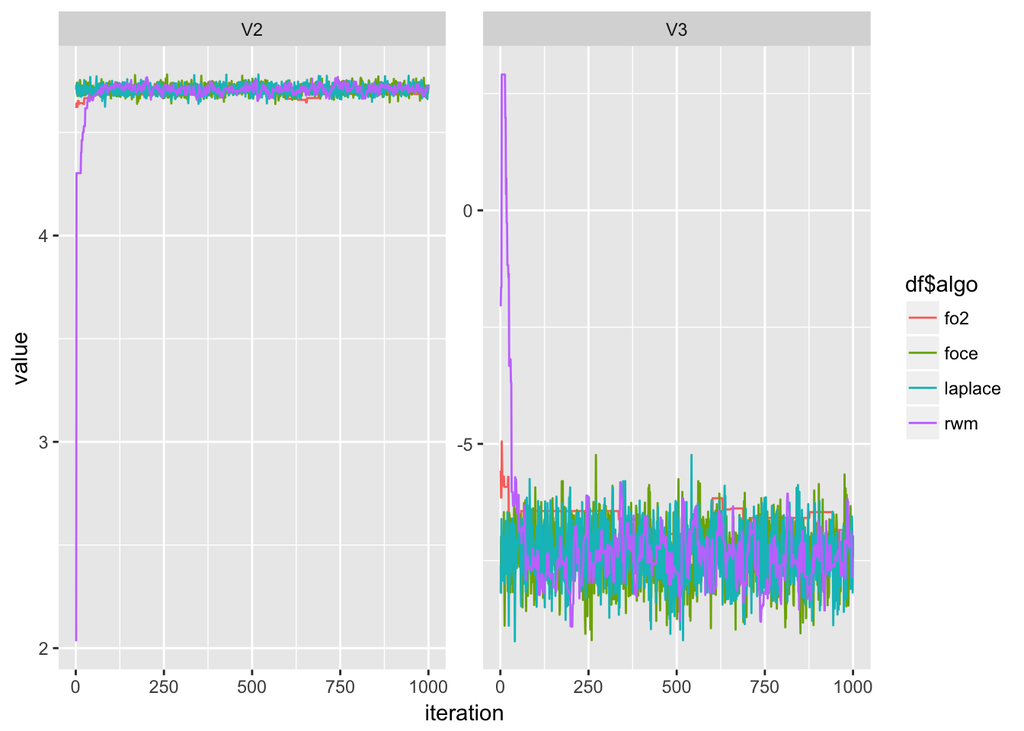

### Yield (37 individuals 224 observations)

$$f(\psi_i) = Y_{max} +B(x-X_{max})$$
Where $\psi = (X_{max},Y_{max},B)$

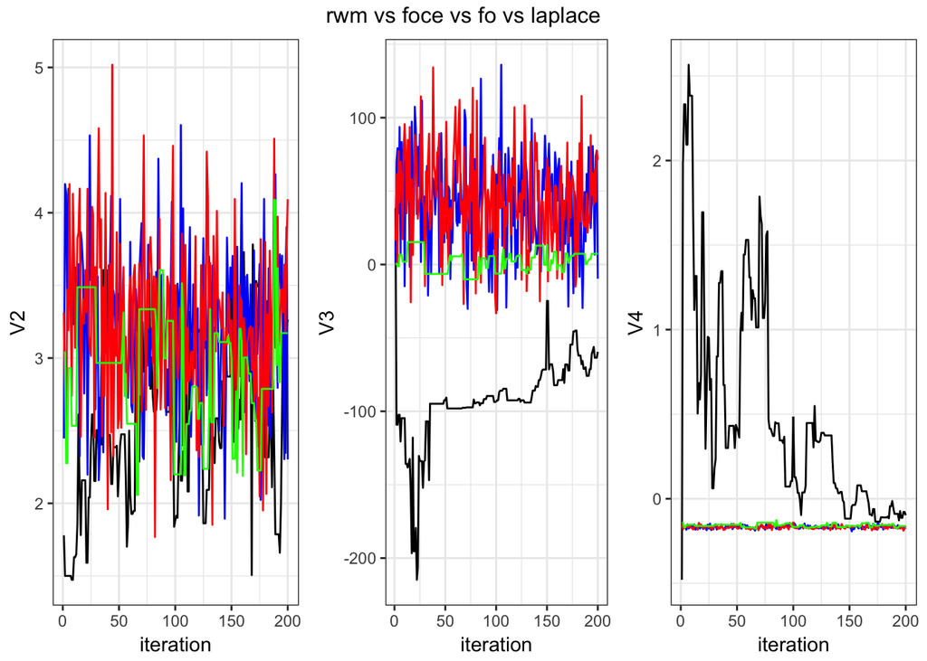

#### Autocorr and msjd

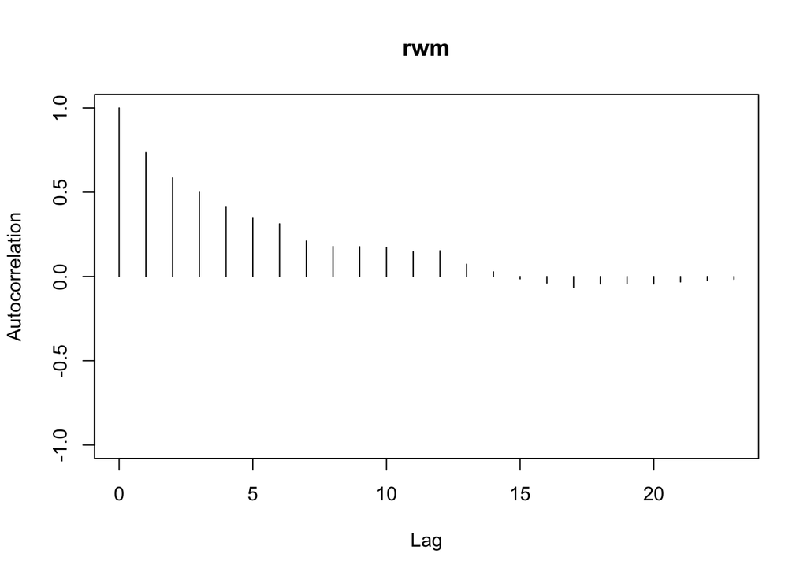

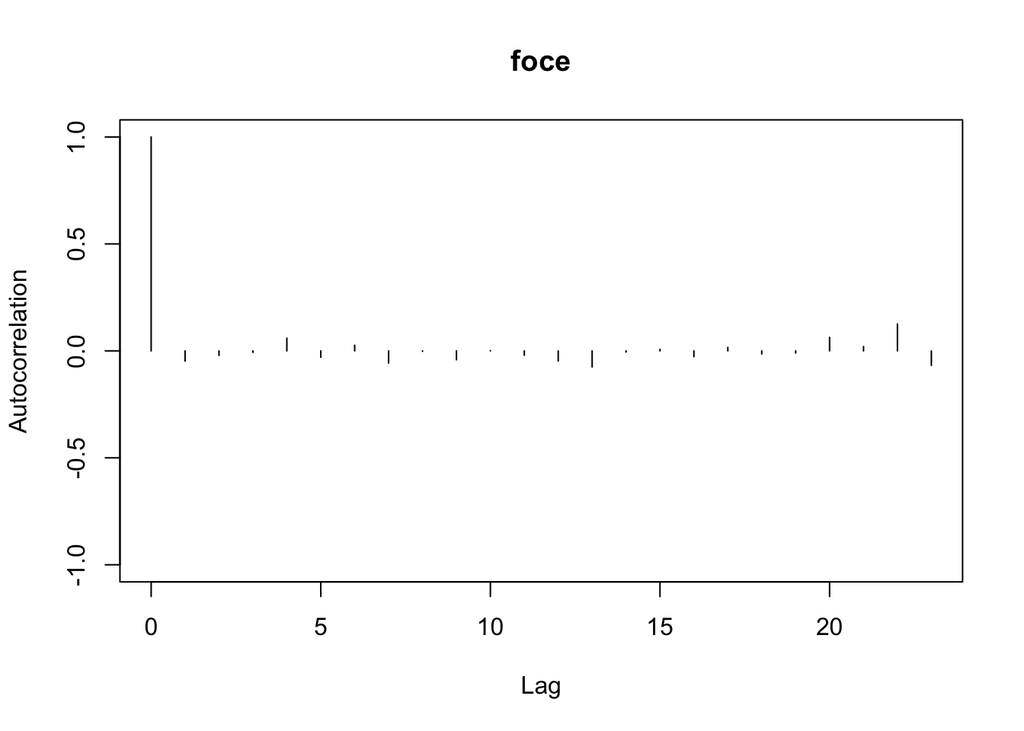

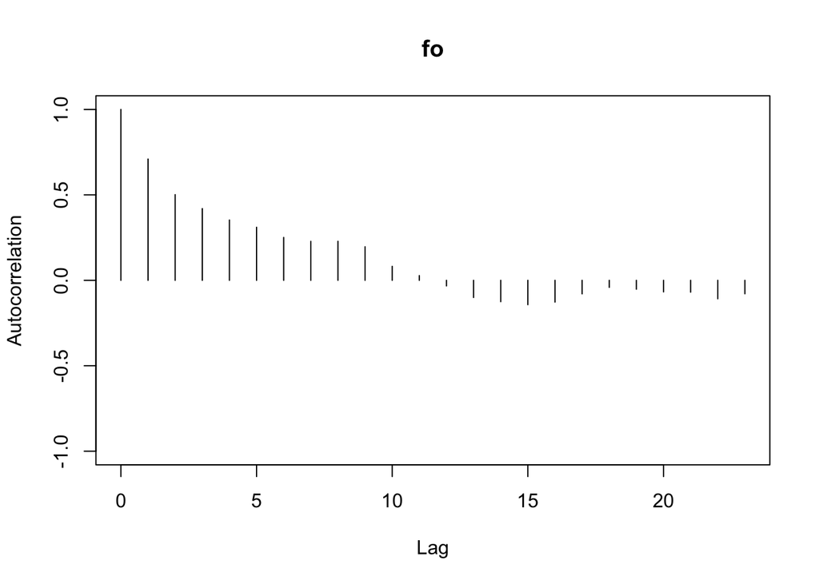

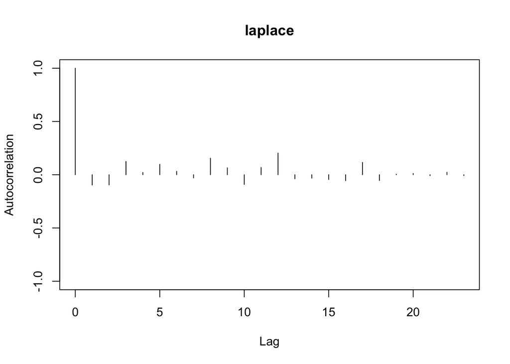

# SAEM coupled with an MCMC procedure for non linear mixed effects models

In this section we focus on the FOCE method. We will loop the mcmc procedure with the SAEM updates. In this case the parameter estimate $\theta$ becomes the quantity of interest. We will first compare the regular SAEM (6 RWM transition kernel in the MCMC procedure) and the best new one (1 RWM kernel and 5 FOCE transition) where at each iteration of the SAEM, the MAP is calculated.

### Yield example

#### SAEM ref vs SAEM_FOCE

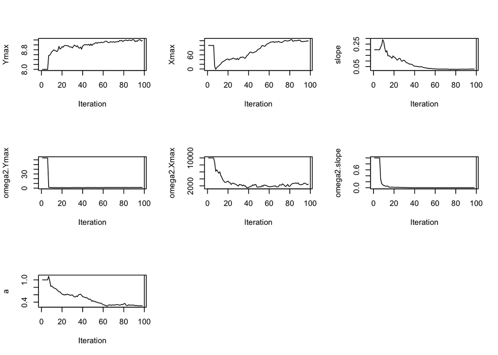

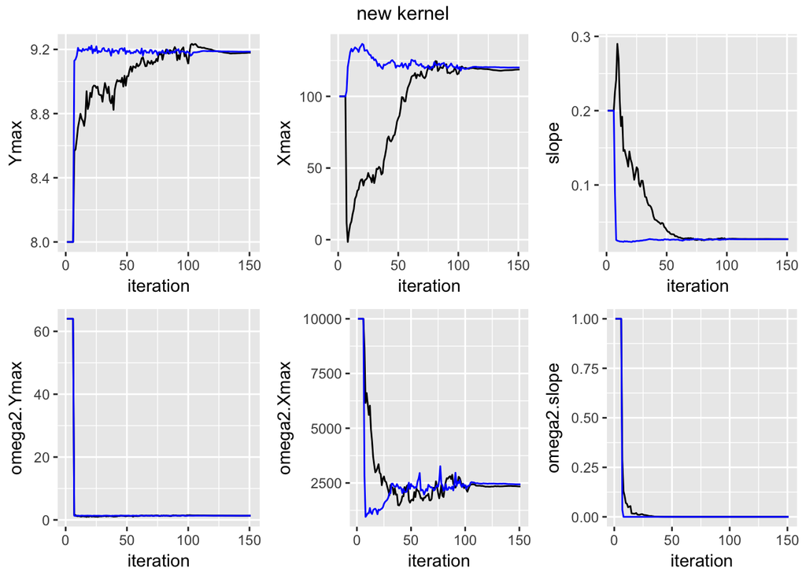

[figure not shown]

#### SAEM ref vs SAEM_FOCE_GD

Since computing the MAP at each SAEM iteration is costly, we could imagine computing the MAP first and then do a gradient descent step towards the gradient of the log posterior to update the MAP at each iteration

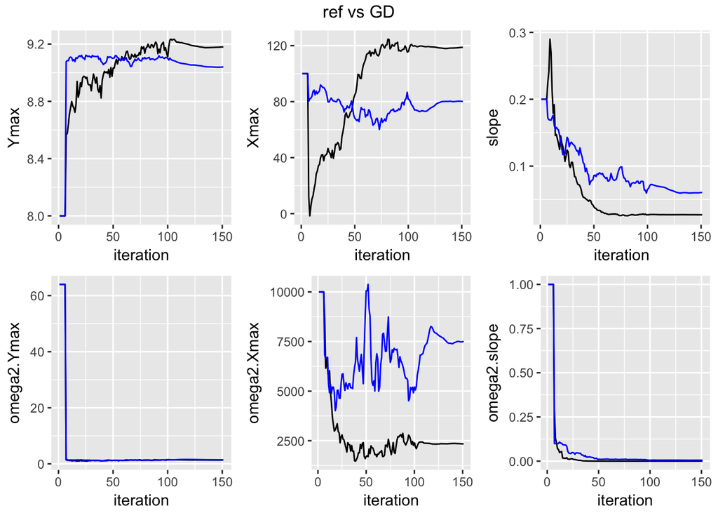

#### SAEM ref vs SAEM_MIX_FOCE_RWM

Another solution consists in mixing the costly algorithm with RWM. Basically, we compute the MAP for the first X iterations, propose via the same independent proposal and then switch to the RWM. According to the models (linear gaussian, Theo, Cow, YieldLP) the number of times the MAP has to be computed at the beginning varies but for all cases it is always better to propose via the FOCE proposal during the first iterations of SAEM and then switch to the regular RWM rather than using this new kernel from time to time.

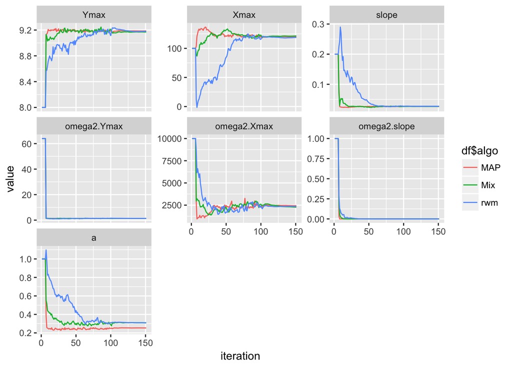